# Evidencia2

Grupo 1

2022-09-04

librerías

```r
library("stats")
library("psych")
library("readxl")
library("MASS")
library("ISLR")
library("fRegression")
library("vcd")
library("dplyr")
library("openxlsx")
```

```r
getwd()
```

```
## [1] "C:/Users/User/Documents/Tec de Monterrey/Analysis de Datos/Evidencia2"
```

```r
setwd("C:/Users/User/Documents/Tec de Monterrey/Analysis de Datos/Evidencia2")
fondo <- read_excel("Fojal.xlsx")
str(fondo)
```

```
## tibble [4,000 × 8] (S3: tbl_df/tbl/data.frame)
##  $ ID     : num [1:4000] 1 1 1 1 1 1 2 2 2 2 ...
##  $ Year   : num [1:4000] 1999 2000 2001 2002 2003 ...
##  $ Default: num [1:4000] 0 0 0 0 0 0 0 0 0 0 ...
##  $ WC/TA  : num [1:4000] 0.501 0.548 0.451 0.307 0.447 ...
##  $ RE/TA  : num [1:4000] 0.307 0.322 0.225 0.192 0.217 ...
##  $ EBIT/TA: num [1:4000] 0.0434 0.0518 0.0268 0.0301 0.0325 ...
##  $ ME/TL  : num [1:4000] 0.956 1.065 0.804 0.387 0.792 ...
##  $ S/TA   : num [1:4000] 0.335 0.335 0.246 0.253 0.276 ...
```

Check para missing values

```r
fondo[!complete.cases(fondo),]
```

```
## # A tibble: 0 × 8
## # … with 8 variables: ID <dbl>, Year <dbl>, Default <dbl>, WC/TA <dbl>,
## #   RE/TA <dbl>, EBIT/TA <dbl>, ME/TL <dbl>, S/TA <dbl>
```

No hay missing values!

Crear dummy variables para aprobadas y no aprobadas:

```r
fondo$aprobado <- ifelse(fondo$Default==0, 1, 0)
fondo$no_aprobado <- ifelse(fondo$Default==1, 1, 0)
mean(fondo$aprobado)
```

```
## [1] 0.982
```

0 significa que el credito es aprobado. Hay más creditos que son aprobados (98,2%). El estar cerca de 1 podemos inferir con la estadística descriptiva que tenemos mas gente siendo aprobada para los créditos que personas que no.

```r
fondo <- select(fondo, ID, Year, Default, `WC/TA`, `RE/TA`, `EBIT/TA`, `ME/TL`, `S/TA`)
```

Seperar la base de datos en Test y Train.

```r
library("caret")

set.seed(11)
train = createDataPartition(y = fondo$Default, p=0.8, list=FALSE, times = 1)
datos_train = fondo[train,]
datos_test = fondo[-train,]
```

Usamos el modelo_probit de la Evidencia 1 porque ese modelo fue mejor que el modelo_logístico.

```r
modelo_probit = glm(Default~., data=fondo, family = binomial(link="probit"))
```

Forward Model

```r
modelo_forward <- step(modelo_probit, direction = "forward", data=datos_train)
```

```
## Start:  AIC=487.91
## Default ~ ID + Year + `WC/TA` + `RE/TA` + `EBIT/TA` + `ME/TL` +
##     `S/TA`
```

```r
summary(modelo_forward)
```

```
##
## Call:
## glm(formula = Default ~ ID + Year + `WC/TA` + `RE/TA` + `EBIT/TA` +
##     `ME/TL` + `S/TA`, family = binomial(link = "probit"), data = fondo)
##
## Deviance Residuals:
##     Min       1Q   Median       3Q      Max
## -1.7182  -0.1690  -0.0661  -0.0188   4.4288
##
## Coefficients:
##               Estimate Std. Error z value Pr(>|z|)
## (Intercept)  1.052e+02  4.578e+01   2.299 0.021533 *
## ID           2.714e-03  3.847e-04   7.054 1.73e-12 ***
## Year        -5.407e-02  2.289e-02  -2.362 0.018156 *
## `WC/TA`      2.143e-01  2.950e-01   0.727 0.467498
## `RE/TA`     -8.568e-01  1.278e-01  -6.702 2.06e-11 ***
## `EBIT/TA`   -5.458e+00  1.446e+00  -3.774 0.000161 ***
## `ME/TL`     -3.699e-01  1.022e-01  -3.620 0.000295 ***
## `S/TA`       3.087e-01  1.976e-01   1.562 0.118317
## ---
## Signif. codes:  0 '***' 0.001 '**' 0.01 '*' 0.05 '.' 0.1 ' ' 1
##
## (Dispersion parameter for binomial family taken to be 1)
##
##     Null deviance: 721.20  on 3999  degrees of freedom
## Residual deviance: 471.91  on 3992  degrees of freedom
## AIC: 487.91
##
## Number of Fisher Scoring iterations: 12
```

Backward Model

```r
modelo_backward <- step(modelo_probit, direction = "backward", data=datos_train)
```

```r
summary(modelo_backward)
```

```
##
## Call:
## glm(formula = Default ~ ID + Year + `RE/TA` + `EBIT/TA` + `ME/TL` +
##     `S/TA`, family = binomial(link = "probit"), data = fondo)
##
## Deviance Residuals:
##     Min       1Q   Median       3Q      Max
## -1.6994  -0.1721  -0.0676  -0.0192   4.4429
##
## Coefficients:
##               Estimate Std. Error z value Pr(>|z|)
## (Intercept)  1.078e+02  4.574e+01   2.357 0.018432 *
## ID           2.696e-03  3.829e-04   7.042  1.9e-12 ***
## Year        -5.535e-02  2.287e-02  -2.420 0.015509 *
## `RE/TA`     -8.355e-01  1.255e-01  -6.657  2.8e-11 ***
## `EBIT/TA`   -5.402e+00  1.450e+00  -3.725 0.000196 ***
## `ME/TL`     -3.604e-01  1.015e-01  -3.549 0.000386 ***
## `S/TA`       3.245e-01  1.953e-01   1.662 0.096501 .
## ---
## Signif. codes:  0 '***' 0.001 '**' 0.01 '*' 0.05 '.' 0.1 ' ' 1
##
## (Dispersion parameter for binomial family taken to be 1)
##
##     Null deviance: 721.20  on 3999  degrees of freedom
## Residual deviance: 472.43  on 3993  degrees of freedom
## AIC: 486.43
##
## Number of Fisher Scoring iterations: 12
```

Entrenar el modelo “Backward”.

```r
datos_train$Default <- as.factor(datos_train$Default)

modelo_crédito<-train(Default ~ ID + `RE/TA` + `EBIT/TA` + `ME/TL` + `S/TA`, data=datos_train, method="glm", family=binomial(link="logit"))
modelo_crédito
```

```
## Generalized Linear Model
##
## 3200 samples
##    5 predictor
##    2 classes: '0', '1'
##
## No pre-processing
## Resampling: Bootstrapped (25 reps)
## Summary of sample sizes: 3200, 3200, 3200, 3200, 3200, 3200, ...
## Resampling results:
##
##   Accuracy  Kappa
##   0.986083  0.4568863
```

```r
modelo_crédito$finalModel
```

```
##
## Call:  NULL
##
## Coefficients:
##     (Intercept)               ID    `\\`RE/TA\\``  `\\`EBIT/TA\\``
##       -6.086912         0.007596        -1.285149        -8.615108
##   `\\`ME/TL\\``     `\\`S/TA\\``
##       -1.799045         0.525633
##
## Degrees of Freedom: 3199 Total (i.e. Null);  3194 Residual
## Null Deviance:       604
## Residual Deviance: 358.4     AIC: 370.4
```

Predecir los resultados

```r
predictTest <- predict(modelo_crédito, datos_test)
pred_credit <- predict(modelo_crédito, datos_test, type="prob")
head(predictTest, 5)
```

```
## [1] 0 0 0 0 0
## Levels: 0 1
```

```r
head(pred_credit, 5)
```

```
##           0            1
## 1 0.9996357 0.0003642949
## 2 0.9978877 0.0021123423
## 3 0.9995577 0.0004423160
## 4 0.9995579 0.0004420882
## 5 0.9996105 0.0003895306
```

```r
predictTest <- as.numeric(levels(predictTest))[predictTest]

cor(datos_test$Default, predictTest)
```

```
## [1] 0.5196054
```

Matriz de confusión para el modelo “Backward”:

```r
predicciones1 <- ifelse(pred_credit$`1` > 0.22, yes = 1, no = 0)
matriz_confusion <- table(predicciones1,datos_test$Default,dnn = c( "predicciones","observaciones"))
matriz_confusion
```

```
##             observaciones
## predicciones   0   1
##            0 786   7
##            1   3   4
```

```r
Recall <- matriz_confusion[2,2]/(matriz_confusion[2,2]+matriz_confusion[1,2])
Recall
```

```
## [1] 0.3636364
```

```r
Precision <- matriz_confusion[2,2]/(matriz_confusion[2,2]+matriz_confusion[2,1])
Precision
```

```
## [1] 0.5714286
```

Modelo Lasso

```r
library("glmnet")
x = model.matrix(Default ~ ., fondo)[,-3]
y = fondo$Default
```

Calculamos el mejor valor para lambda.

```r
set.seed(123)
cv_model = cv.glmnet(x,y,family="binomial",alpha=1)
bestlambda = cv_model$lambda.min
bestlambda
```

```
## [1] 0.0004878752
```

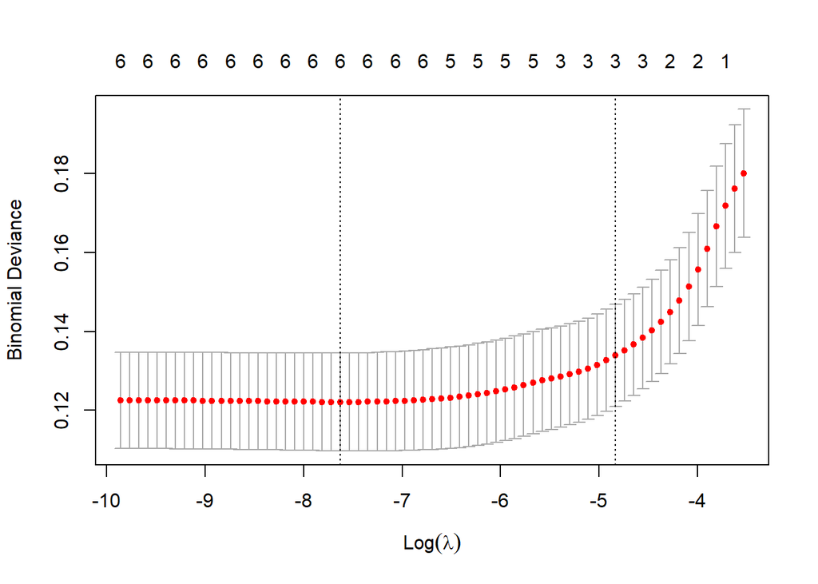

```r
plot(cv_model)
```

Es importante de estandardizar los variables.

```r
set.seed(1)
best_lasso = glmnet(x,y,alpha=1, family="binomial", lambda=bestlambda, standardize = T)
coef(best_lasso)
```

```
## 8 x 1 sparse Matrix of class "dgCMatrix"
##                       s0
## (Intercept) -6.644548519
## (Intercept)  .
## ID           0.007524463
## `WC/TA`      0.356301815
## `RE/TA`     -1.615346174
## `EBIT/TA`   -9.182746172
## `ME/TL`     -0.788710365
## `S/TA`       0.456015103
```

Predicimos los resultados de la base de datos datos_test.

```r
predLlink <- predict(best_lasso, as.matrix(datos_test[,1:7]), type="link")
predLprobs <- predict(best_lasso, as.matrix(datos_test[,1:7]), type="response")
predLlink[1:10]
```

```
##  [1]  5.961412  8.692846  7.402666  7.186045  8.741585  6.374847  7.147483
##  [8]  6.633996  9.479622 10.514285
```

```r
predLprobs[1:10]
```

```
##  [1] 0.9974303 0.9998322 0.9993907 0.9992435 0.9998402 0.9982990 0.9992138
##  [8] 0.9986868 0.9999236 0.9999729
```

Matriz de confusión de modelo Lasso:

Para el modelo Lasso se requieren un valor de Cutoff alto porque las probabilidades son casi 1 para la mayoría de los predicciones.

```r
predicciones2 <- ifelse(predLprobs > 0.99995, yes = 1, no = 0)
matriz_confusion2 <- table(predicciones2, datos_test$Default)
matriz_confusion2
```

```
##
## predicciones2   0   1
##             0 738   4
##             1  51   7
```

```r
Recall <- matriz_confusion2[2,2]/(matriz_confusion2[2,2]+matriz_confusion2[1,2])
Recall
```

```
## [1] 0.6363636
```

```r
Precision <- matriz_confusion2[2,2]/(matriz_confusion2[2,2]+matriz_confusion2[2,1])
Precision
```

```
## [1] 0.1206897
```

El que sigue es la prueba de usar un red neuronal:

```r
library("neuralnet")
set.seed(123)
#RN <- neuralnet(Default ~ .,
#               data = fondo,
 #              hidden = c(12,7),
  #             linear.output = F,
   #            lifesign = 'full',
    #           threshold = 0.05,
     #          rep=1)
```

Por algún razón no podemos insertar los variables en la formula. Solo funciona con ID y Year. `WC/TA` por ejemploo no funciona y recibimos un error. Por eso, no podemos continuar con la análisis con el red neuronal :(